# STATlast

Ruohan wang

2019/5/4

```r
library(mcsm)
data(challenger)
head(challenger)
```

```
##   oring temp
## 1     1   53
## 2     1   57
## 3     1   58
## 4     1   63
## 5     0   66
## 6     0   67
```

```r
str(challenger)
```

```
## 'data.frame':    23 obs. of  2 variables:
##  $ oring: int  1 1 1 1 0 0 0 0 0 0 ...
##  $ temp : int  53 57 58 63 66 67 67 67 68 69 ...
```

```r
model1 = glm(oring~temp,data = challenger, family = binomial)
summary(model1)
```

```
##
## Call:
## glm(formula = oring ~ temp, family = binomial, data = challenger)
##
## Deviance Residuals:
##     Min       1Q   Median       3Q      Max
## -1.0611  -0.7613  -0.3783   0.4524   2.2175
##
## Coefficients:
##             Estimate Std. Error z value Pr(>|z|)
## (Intercept)  15.0429     7.3786   2.039   0.0415 *
## temp         -0.2322     0.1082  -2.145   0.0320 *
## ---
## Signif. codes:  0 '***' 0.001 '**' 0.01 '*' 0.05 '.' 0.1 ' ' 1
##
## (Dispersion parameter for binomial family taken to be 1)
##
##     Null deviance: 28.267  on 22  degrees of freedom
## Residual deviance: 20.315  on 21  degrees of freedom
## AIC: 24.315
##
## Number of Fisher Scoring iterations: 5
```

```r
#Interpret Coefficients:
#logit scale
coef(model1)
```

```
## (Intercept)        temp
##  15.0429016  -0.2321627
```

Interpret: The coefficient for beta 1 temp is -0.2322, which is negtive. This means the probability of a oring suceese or fail decrease with increasing temp. When the 1 temperature increase, the log odds decrease by 0.2322.  
The estimate adds ratio of a oring pr esent is exp(-0.2322) = 0.79278754994 . When the 1 temperature increase, the odds decrease by (1-0.79278754994)*100% = 21% .  
The estimated probability of a oring being present is 50%, when the temp is -beta0hat/beta1hat = 15.0429 /0.2322 = 64.7842377261 temp.

Relationship between temperature and o-ring failure: Assume the prob of success is p(x), the prob of fail is 1-p(x) so we know the p(x) = exp(beta0+ beta1*x ) / 1+ exp (beta 0 +beta1* x) so 1- p(x) = 1- exp(beta0+ beta1*x ) / 1+ exp (beta 0 +beta1* x)

# b.

# c.

The coefficient for beta 1 temp is -0.2322, which is negtive. This means the probability of a oring suceese or fail decrease with increasing temp.

When the 1 temperature increase, the log odds decrease by 0.2322.

The estimate adds ratio of a oring pr esent is exp(-0.2322) = 0.79278754994 . When the 1 temperature increase, the odds decrease by

(1-0.79278754994)*100% = 21% .

The estimated probability of a oring being present is 50%, when the temp is -beta0hat/beta1hat = 15.0429 /0.2322 = 64.7842377261 temp.

# d.

choose 0 and 1

logit ratio :

logit(1)/logit(0) = (beta0+ beta1*1 )/ (beta0+ beta1*0 ) = (15.0429016 -0.2321627 )/ 15.0429016 =0.98456662775

odds ratio:

odd(1)/odds(0) = prob(1)/ (1-prob(1)) /prob(0)/(1-prob(0))  
output prob 1 and prob 0 first. Prob 1 =exp(15.0429016 -0.2321627*1 ) / (1+ exp (15.0429016-0.2321627* 1)) = 0.99999963036 prob 0 =exp(15.0429016 -0.2321627*0 ) / (1+ exp (15.0429016-0.2321627* 0)) = 0.99999970694

e.Assess the accuracy of the model created in part a.

```r
#accuracy
p=predict(model1,type="response")
table(challenger$oring,p>0.5)
```

```
##
##     FALSE TRUE
##   0    16    0
##   1     3    4
```

acc = 20 / 23 = 0.869 so the accuracy is 0.869.

2.(a)

```r
field.goal<-read.table("http://users.stat.ufl.edu/~winner/data/fieldgoal.dat")
colnames(field.goal)<-c("yards","success","week")
head(field.goal)
```

```
##   yards success week
## 1    30       1    1
## 2    41       1    1
## 3    50       1    1
## 4    22       1    1
## 5    33       1    1
## 6    44       1    1
```

```r
tail(field.goal)
```

```
##     yards success week
## 943    31       1   17
## 944    42       1   17
## 945    46       1   17
## 946    47       1   17
## 947    52       0   17
## 948    51       0   17
```

```r
str(field.goal)
```

```
## 'data.frame':    948 obs. of  3 variables:
##  $ yards  : int  30 41 50 22 33 44 40 55 49 51 ...
##  $ success: int  1 1 1 1 1 1 1 0 1 1 ...
##  $ week   : int  1 1 1 1 1 1 1 1 1 1 ...
```

```r
model2 = glm (success~ yards+ week,family = binomial , data = field.goal)
model2.1 =  glm (success~ yards* week,family = binomial , data = field.goal)
summary(model2)
```

```
##
## Call:
## glm(formula = success ~ yards + week, family = binomial, data = field.goal)
##
## Deviance Residuals:
##     Min       1Q   Median       3Q      Max
## -2.6338   0.2443   0.4046   0.7012   1.3963
##
## Coefficients:
##             Estimate Std. Error z value Pr(>|z|)
## (Intercept)  6.29969    0.51105  12.327   <2e-16 ***
## yards       -0.11274    0.01076 -10.477   <2e-16 ***
## week        -0.05243    0.01832  -2.862   0.0042 **
## ---
## Signif. codes:  0 '***' 0.001 '**' 0.01 '*' 0.05 '.' 0.1 ' ' 1
##
## (Dispersion parameter for binomial family taken to be 1)
##
##     Null deviance: 955.38  on 947  degrees of freedom
## Residual deviance: 808.86  on 945  degrees of freedom
## AIC: 814.86
##
## Number of Fisher Scoring iterations: 5
```

```r
summary(model2.1)
```

```
##
## Call:
## glm(formula = success ~ yards * week, family = binomial, data = field.goal)
##
## Deviance Residuals:
##     Min       1Q   Median       3Q      Max
## -2.7013   0.2302   0.4150   0.7058   1.4410
##
## Coefficients:
##              Estimate Std. Error z value Pr(>|z|)
## (Intercept)  6.917057   1.030909   6.710 1.95e-11 ***
## yards       -0.127262   0.023537  -5.407 6.41e-08 ***
## week        -0.117452   0.094158  -1.247    0.212
## yards:week   0.001553   0.002202   0.705    0.481
## ---
## Signif. codes:  0 '***' 0.001 '**' 0.01 '*' 0.05 '.' 0.1 ' ' 1
##
## (Dispersion parameter for binomial family taken to be 1)
##
##     Null deviance: 955.38  on 947  degrees of freedom
## Residual deviance: 808.36  on 944  degrees of freedom
## AIC: 816.36
##
## Number of Fisher Scoring iterations: 5
```

```r
anova(model2,model2.1)
```

```
## Analysis of Deviance Table
##
## Model 1: success ~ yards + week
## Model 2: success ~ yards * week
##   Resid. Df Resid. Dev Df Deviance
## 1       945     808.86
## 2       944     808.36  1  0.49749
```

choose model 2 Interpret the estimates of the predictors in your final model and discuss how they influence field goal success.

The p value for the yards and week are <2e-16 and 0.0042 respectively so both of these two variables are significant and the

coeffiecent of these two variables are -0.11274 and -0.05243, so the logit will decrease 0.11274 by per unit increase of yards and decrease

0.05243 by per unit increase of week. AIC is pretty big so the model can be modified in some way.

2(b)

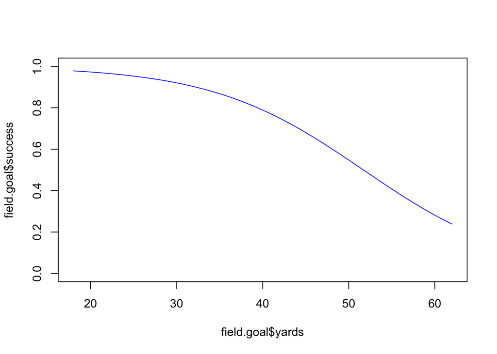

```r
#plot
#because the model2 indicates that the yard and week are important, so
plot(field.goal$yards,field.goal$success,ylim = c(0,1),type="n")
xyyards = seq(18,62,length=948)
lines(field.goal$yards<-xyyards)
yfit = predict(model2,data.frame(yards=xyyards,week=9),type = "response")
lines(xyyards, yfit, col = "blue")
```

2(c)

```r
mean(field.goal$week)
```

```
## [1] 8.989451
```

predicted one, so we have the logit = log(0.5/0.5) = 0, so we are supposes to calculate the beta1*yards +beata2*week +beata 0 >0

-0.11274 *yards -0.05243* week_bar +6.29969 > 0

so (0.05243 *8.989451 - 6.29969)/-0.11274 = 51.6974728053

Thus should be 51.6974728053 yards away.

2(d) logit = -0.11274 *60 -0.05243* 9 +6.29969 = -0.93658 p(x) = exp(-0.93658) /(1+exp(-0.93658) )= 0.28159168401 so the probibility of success is 0.28159168401

2(e) Obviously it is the yards affect most. -0.11274 for yards and -0.05243 for week. What affects the odds ratio is the sam e variable affect logit most. Log( odds ) and odds tendency is the same.

```r
yardsfit = exp(-0.11274 )
weekfit = exp(-0.05243)
yardsfit
```

```
## [1] 0.8933829
```

```r
weekfit
```

```
## [1] 0.9489207
```

2(f) AIC = devianece+ 2*p = 808.86+2*3 = 814.86

3.(a)

```r
data3<-read.table("https://www2.stat.duke.edu/courses/Fall09/sta114/data/Hand/psycho.dat")
colnames(data3)<-c("sex","age.group","mean.age","GHQ","num.taking.drug","total.num")
head(data3)
```

```
##   sex age.group mean.age GHQ num.taking.drug total.num
## 1   0     16-29     23.2   0               9       531
## 2   0     30-44     36.5   0              16       500
## 3   0     45-64     54.3   0              38       644
## 4   0     65-74     69.2   0              26       275
## 5   0       >74     79.5   0               9        90
## 6   0     16-29     23.2   1              12       171
```

```r
str(data3)
```

```
## 'data.frame':    20 obs. of  6 variables:
##  $ sex            : int  0 0 0 0 0 0 0 0 0 0 ...
##  $ age.group      : Factor w/ 5 levels ">74","16-29",..: 2 3 4 5 1 2 3 4 5 1 ...
##  $ mean.age       : num  23.2 36.5 54.3 69.2 79.5 23.2 36.5 54.3 69.2 79.5 ...
##  $ GHQ            : int  0 0 0 0 0 1 1 1 1 1 ...
##  $ num.taking.drug: int  9 16 38 26 9 12 16 31 16 10 ...
##  $ total.num      : int  531 500 644 275 90 171 125 121 56 26 ...
```

```r
num.not.take = data3$total.num - data3$num.taking.drug
model3.1 = glm(cbind(num.taking.drug, num.not.take)~    sex+GHQ+age.group,data = data3, family = binomial)
summary(model3.1)
```

```
##
## Call:
## glm(formula = cbind(num.taking.drug, num.not.take) ~ sex + GHQ +
##     age.group, family = binomial, data = data3)
##
## Deviance Residuals:
##      Min        1Q    Median        3Q       Max
## -1.69383  -0.38364   0.03628   0.40832   1.45093
##
## Coefficients:
##                Estimate Std. Error z value Pr(>|z|)
## (Intercept)    -2.30464    0.16047 -14.361  < 2e-16 ***
## sex             0.62780    0.09554   6.571 4.98e-11 ***
## GHQ             1.41364    0.09047  15.626  < 2e-16 ***
## age.group16-29 -1.70073    0.19004  -8.949  < 2e-16 ***
## age.group30-44 -0.93266    0.17064  -5.466 4.61e-08 ***
## age.group45-64 -0.38920    0.15750  -2.471   0.0135 *
## age.group65-74  0.03563    0.17096   0.208   0.8349
## ---
## Signif. codes:  0 '***' 0.001 '**' 0.01 '*' 0.05 '.' 0.1 ' ' 1
##
## (Dispersion parameter for binomial family taken to be 1)
##
##     Null deviance: 467.183  on 19  degrees of freedom
## Residual deviance:  14.309  on 13  degrees of freedom
## AIC: 125.59
##
## Number of Fisher Scoring iterations: 4
```

So from this model, we can know that except age.group65-74 all the group are significant to the result. Sex age and GHQ are statistically

significant predictors of drug compliance.age.group16-29 taking drug decreases the log odds of taking drug by 1.70073.

age.group30-44 taking drug decreases the log odds of taking drug by 0.93266.

age.group45-64 taking drug decreases the log odds of taking drug by 0.38920.

age.group65-74 taking drug increases the log odds of taking drug by 0.03563.

3(b)

```r
data3$age.group = as.numeric(data3$age.group )
model3.b= glm(cbind(num.taking.drug, num.not.take)~ sex+age.group+GHQ,data = data3, family = binomial)
summary(model3.b)
```

```
##
## Call:
## glm(formula = cbind(num.taking.drug, num.not.take) ~ sex + age.group +
##     GHQ, family = binomial, data = data3)
##
## Deviance Residuals:
##     Min       1Q   Median       3Q      Max
## -4.7727  -1.2979   0.2384   1.3179   5.9531
##
## Coefficients:
##             Estimate Std. Error z value Pr(>|z|)
## (Intercept) -3.97660    0.16421 -24.216  < 2e-16 ***
## sex          0.67361    0.09436   7.139 9.43e-13 ***
## age.group    0.30575    0.03947   7.747 9.43e-15 ***
## GHQ          1.36057    0.08891  15.303  < 2e-16 ***
## ---
## Signif. codes:  0 '***' 0.001 '**' 0.01 '*' 0.05 '.' 0.1 ' ' 1
##
## (Dispersion parameter for binomial family taken to be 1)
##
##     Null deviance: 467.18  on 19  degrees of freedom
## Residual deviance: 125.63  on 16  degrees of freedom
## AIC: 230.91
##
## Number of Fisher Scoring iterations: 5
```

```r
library(aod)
wald.test(b=coef(model3.1),Sigma=vcov(model3.1),Terms=4:7)
```

```
## Wald test:
## ----------
##
## Chi-squared test:
## X2 = 149.9, df = 4, P(> X2) = 0.0
```

After tranfermation, we can tell the significance of age.group is TRUE. Because the p value is 9.43e-15, it is very significant. WALD -> p_val of the age.group is 0.

3(c)

```r
model3.2 = glm(cbind( num.not.take,num.taking.drug)~    sex+age.group+GHQ,data = data3, family = binomial)
summary(model3.2)
```

```
##
## Call:
## glm(formula = cbind(num.not.take, num.taking.drug) ~ sex + age.group +
##     GHQ, family = binomial, data = data3)
##
## Deviance Residuals:
##     Min       1Q   Median       3Q      Max
## -5.9531  -1.3179  -0.2384   1.2979   4.7727
##
## Coefficients:
##             Estimate Std. Error z value Pr(>|z|)
## (Intercept)  3.97660    0.16421  24.216  < 2e-16 ***
## sex         -0.67361    0.09436  -7.139 9.43e-13 ***
## age.group   -0.30575    0.03947  -7.747 9.43e-15 ***
## GHQ         -1.36057    0.08891 -15.303  < 2e-16 ***
## ---
## Signif. codes:  0 '***' 0.001 '**' 0.01 '*' 0.05 '.' 0.1 ' ' 1
##
## (Dispersion parameter for binomial family taken to be 1)
##
##     Null deviance: 467.18  on 19  degrees of freedom
## Residual deviance: 125.63  on 16  degrees of freedom
## AIC: 230.91
##
## Number of Fisher Scoring iterations: 5
```

Above is. All coeffients change the symbol.

4(a)

```r
smoker = c("yes","no")
dead = c(6+1,24+14)
alive = c(459+124,4012+1594)
model4.1 = glm(cbind (dead,alive)~smoker,data.frame(smoker,dead,alive),family = binomial)
summary(model4.1)
```

```
##
## Call:
## glm(formula = cbind(dead, alive) ~ smoker, family = binomial,
##     data = data.frame(smoker, dead, alive))
##
## Deviance Residuals:
## [1]  0  0
##
## Coefficients:
##             Estimate Std. Error z value Pr(>|z|)
## (Intercept)  -4.9940     0.1628 -30.681   <2e-16 ***
## smokeryes     0.5717     0.4136   1.382    0.167
## ---
## Signif. codes:  0 '***' 0.001 '**' 0.01 '*' 0.05 '.' 0.1 ' ' 1
##
## (Dispersion parameter for binomial family taken to be 1)
##
##     Null deviance:  1.6773e+00  on 1  degrees of freedom
## Residual deviance: -1.2879e-13  on 0  degrees of freedom
## AIC: 13.269
##
## Number of Fisher Scoring iterations: 3
```

Because the coefficient for somker is 0.5717>0, so smoking increases a baby???s risk of death.

4(b)

```r
#prediction by hand
OR1 = (7/38) / (583/5606)
OR1
```

```
## [1] 1.771328
```

```r
#confirm using predict function
beta1=0.5717
OR2 = exp( 0.5717)
OR2
```

```
## [1] 1.771276
```

Two data are same. Thus confirmed.

4(c)

```r
chisq.test(cbind (dead,alive),correct = FALSE)
```

```
##
##  Pearson's Chi-squared test
##
## data:  cbind(dead, alive)
## X-squared = 1.9628, df = 1, p-value = 0.1612
```

So there does not exist association between a mother???s smoking and an increase risk of death.

4(d)

```r
age = c("young","young","old","old")
smoke= c("yes","no","yes","no")
dead = c(6,24,1,14)
alive = c(459,4012,124,1594)
model4.d1 = glm(cbind(dead,alive)~smoke+age, data.frame(age,smoke,dead,alive),family = binomial)
model4.d2 = glm(cbind(dead,alive)~smoke*age, data.frame(age,smoke,dead,alive),family = binomial)
summary(model4.d1)
```

```
##
## Call:
## glm(formula = cbind(dead, alive) ~ smoke + age, family = binomial,
##     data = data.frame(age, smoke, dead, alive))
##
## Deviance Residuals:
##       1        2        3        4
##  0.3629  -0.1702  -0.6834   0.2304
##
## Coefficients:
##             Estimate Std. Error z value Pr(>|z|)
## (Intercept)  -4.7974     0.2643 -18.155   <2e-16 ***
## smokeyes      0.5942     0.4145   1.434    0.152
## ageyoung     -0.2869     0.3182  -0.902    0.367
## ---
## Signif. codes:  0 '***' 0.001 '**' 0.01 '*' 0.05 '.' 0.1 ' ' 1
##
## (Dispersion parameter for binomial family taken to be 1)
##
##     Null deviance: 3.14427  on 3  degrees of freedom
## Residual deviance: 0.68082  on 1  degrees of freedom
## AIC: 21.814
##
## Number of Fisher Scoring iterations: 4
```

```r
anova(model4.d1 ,model4.d2 ,test = "Chisq")
```

```
## Analysis of Deviance Table
##
## Model 1: cbind(dead, alive) ~ smoke + age
## Model 2: cbind(dead, alive) ~ smoke * age
##   Resid. Df Resid. Dev Df Deviance Pr(>Chi)
## 1         1    0.68082
## 2         0    0.00000  1  0.68082   0.4093
```

So we choose model4.d1 = glm(cbind(dead,alive)~smoke+age, data.frame(age,smoke,dead,alive),family = binomial) as our final model.

5. Estimate the odds that a younger mother???s baby dies.

```r
e = (6/24)/(459/4012)
e
```

```
## [1] 2.185185
```

6. Estimate the odds that an older mother???s baby dies.

```r
f= (1/14)/(124/1594)
f
```

```
## [1] 0.9182028
```

7. Estimate the odds ratio of a younger mother???s baby dying compared to an older mother???s baby?

```r
e/f
```

```
## [1] 2.37985
```